# Figure 5: Comparison of `H170` variants

Figure 5 uses panel B to display maximum amplitude and decay rate constants for each of the `H170` mutants at `LPR5` and `LPR10`.

## The Dataset

We process the `NeRh50_Table_S1_raw_data_used_in_figures.csv` dataset to obtain the data for this analysis in Table 1.

```r
# Show interactive tables of data
DT::datatable(dfms$dfm_fig5_amp)
DT::datatable(dfms$dfm_fig5_k)
# Write datasets to file (commented out for website)
#readr::write_csv(dfms$dfm_fig5_amp, "assets/data/03_fig5_amplitude.csv")
#readr::write_csv(dfms$dfm_fig5_k, "assets/data/03_fig5_rate.csv")
```

Table 1: Measurements for `WT` and `H170` variants across `LPR5` and `LPR10` for maximum amplitude and decay rate constant.

(a) Maximum amplitude

|  | Variant | Condition | LPR | Value |
| --- | --- | --- | --- | --- |
| 1 | WT | H2O | LPR5 | 1.981 |
| 2 | WT | H2O | LPR5 | 1.686 |
| 3 | WT | H2O | LPR5 | 2.132 |
| 4 | WT | H2O | LPR5 | 1.988 |
| 5 | WT | H2O | LPR5 | 2.026 |
| 6 | WT | H2O | LPR5 | 1.99 |
| 7 | WT | H2O | LPR5 | 2.118 |
| 8 | WT | H2O | LPR5 | 2.194 |
| 9 | WT | H2O | LPR5 | 2.127 |
| 10 | H170A | H2O | LPR5 | 1.347 |

[output cut: 52 more lines]

(b) Decay rate

|  | Variant | Condition | LPR | Value |
| --- | --- | --- | --- | --- |
| 1 | WT | H2O | LPR5 | 43.69 |
| 2 | WT | H2O | LPR5 | 44.83 |
| 3 | WT | H2O | LPR5 | 42.48 |
| 4 | WT | H2O | LPR5 | 42.58 |
| 5 | WT | H2O | LPR5 | 41.72 |
| 6 | WT | H2O | LPR5 | 49.97 |
| 7 | WT | H2O | LPR5 | 48.32 |
| 8 | WT | H2O | LPR5 | 42.44 |
| 9 | WT | H2O | LPR5 | 42.96 |
| 10 | WT | H2O | LPR10 | 36.13 |

[output cut: 50 more lines]

We visualise the dataset in the style of draft figure 5, in Figure 1.

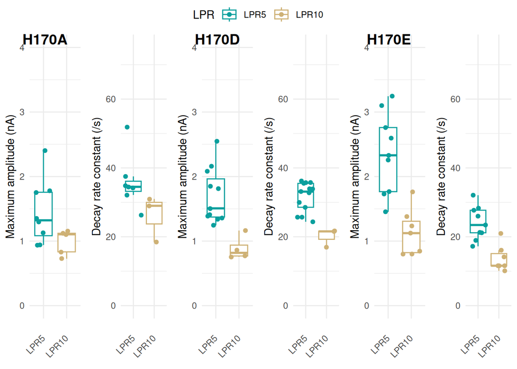

Figure 1: `H170` variant measurements across `LPR5` and `LPR10` as in figure 5B from the draft manuscript

```r
# Visualise datasets as box/whisker with superimposed datapoints
p4_h170a_amp <- ggplot2::ggplot(dfms$dfm_fig5_amp |> dplyr::filter(Variant=="H170A"),
                                ggplot2::aes(x=LPR, y=Value, color=LPR))  +
  ggplot2::geom_boxplot(outlier.shape = NA) +
  ggplot2::geom_jitter() +
  ggplot2::labs(y="Maximum amplitude (nA)", x="") +
  ggplot2::ylim(0, 4) +
  ggplot2::theme_minimal() +
  ggplot2::theme(axis.text.x = ggplot2::element_text(angle = 45, vjust = 0.5, hjust=1))

p4_h170a_k <- ggplot2::ggplot(dfms$dfm_fig5_k |> dplyr::filter(Variant == "H170A"),
                              ggplot2::aes(x=LPR, y=Value, color=LPR))  +
  ggplot2::geom_boxplot(outlier.shape = NA) +
  ggplot2::geom_jitter() +
  ggplot2::labs(y="Decay rate constant (/s)", x="") +
  ggplot2::ylim(0, 75) +
  ggplot2::theme_minimal() +
  ggplot2::theme(axis.text.x = ggplot2::element_text(angle = 45, vjust = 0.5, hjust=1))

p4_h170d_amp <- ggplot2::ggplot(dfms$dfm_fig5_amp |> dplyr::filter(Variant == "H170D"),
                                ggplot2::aes(x=LPR, y=Value, color=LPR)) +
  ggplot2::geom_boxplot(outlier.shape = NA) +
  ggplot2::geom_jitter() +
  ggplot2::labs(y="Maximum amplitude (nA)", x="") +
  ggplot2::ylim(0, 4) +
  ggplot2::theme_minimal() +
  ggplot2::theme(axis.text.x = ggplot2::element_text(angle = 45, vjust = 0.5, hjust=1))

p4_h170d_k <- ggplot2::ggplot(dfms$dfm_fig5_k |> dplyr::filter(Variant == "H170D"),
                              ggplot2::aes(x=LPR, y=Value, color=LPR))  +
  ggplot2::geom_boxplot(outlier.shape = NA) +
  ggplot2::geom_jitter() +
  ggplot2::labs(y="Decay rate constant (/s)", x="") +
  ggplot2::ylim(0, 75) +
  ggplot2::theme_minimal() +
  ggplot2::theme(axis.text.x = ggplot2::element_text(angle = 45, vjust = 0.5, hjust=1))

p4_h170e_amp <- ggplot2::ggplot(dfms$dfm_fig5_amp |> dplyr::filter(Variant == "H170E"),
                                ggplot2::aes(x=LPR, y=Value, color=LPR))  +
  ggplot2::geom_boxplot(outlier.shape = NA) +
  ggplot2::geom_jitter() +
  ggplot2::labs(y="Maximum amplitude (nA)", x="") +
  ggplot2::ylim(0, 4) +
  ggplot2::theme_minimal() +
  ggplot2::theme(axis.text.x = ggplot2::element_text(angle = 45, vjust = 0.5, hjust=1))

p4_h170e_k <- ggplot2::ggplot(dfms$dfm_fig5_k |> dplyr::filter(Variant == "H170E"),
                              ggplot2::aes(x=LPR, y=Value, color=LPR))  +
  ggplot2::geom_boxplot(outlier.shape = NA) +
  ggplot2::geom_jitter() +
  ggplot2::labs(y="Decay rate constant (/s)", x="") +
  ggplot2::ylim(0, 75) +
  ggplot2::theme_minimal() +
  ggplot2::theme(axis.text.x = ggplot2::element_text(angle = 45, vjust = 0.5, hjust=1))

ggpubr::ggarrange(p4_h170a_amp, p4_h170a_k, p4_h170d_amp, p4_h170d_k, p4_h170e_amp, p4_h170e_k,
                  common.legend=TRUE,
                  labels=c("H170A", "", "H170D", "", "H170E", ""),
                  nrow=1
                  )
```

### Downloads

- Download `03_fig5_amplitude.csv`
- Download `03_fig5_rate.csv`

## The Models

We treat the system as a single experiment with two dependent variables (maximum amplitude and decay rate constant), fitting linear models with `LPR` and `Variant` as explanatory variables. We initially fit the full model `Value ~ LPR * Variant` as in Table 2.

```r
model4_amp_lm <- lm(Value ~ LPR * Variant, data=dfms$dfm_fig5_amp)
model4_k_lm <- lm(Value ~ LPR * Variant, data=dfms$dfm_fig5_k)

gtsummary::tbl_regression(model4_amp_lm)
gtsummary::tbl_regression(model4_k_lm)
```

Table 2: Linear model fits of `Value ~ LPR * Variant`

(a) Maximum amplitude

| **Characteristic** | **Beta** | **95% CI** | **p-value** |
| --- | --- | --- | --- |
| LPR |  |  |  |
| LPR5 | — | — |  |
| LPR10 | -0.91 | -1.3, -0.55 | <0.001 |
| Variant |  |  |  |
| WT | — | — |  |
| H170A | -0.58 | -0.96, -0.20 | 0.003 |
| H170D | -0.33 | -0.68, 0.02 | 0.066 |
| H170E | 0.33 | -0.03, 0.70 | 0.075 |
| LPR * Variant |  |  |  |
| LPR10 * H170A | 0.45 | -0.12, 1.0 | 0.12 |
| LPR10 * H170D | 0.10 | -0.48, 0.69 | 0.7 |
| LPR10 * H170E | -0.31 | -0.85, 0.23 | 0.3 |

Abbreviation: CI = Confidence Interval

(b) Decay rate

| **Characteristic** | **Beta** | **95% CI** | **p-value** |
| --- | --- | --- | --- |
| LPR |  |  |  |
| LPR5 | — | — |  |
| LPR10 | -11 | -15, -6.8 | <0.001 |
| Variant |  |  |  |
| WT | — | — |  |
| H170A | -8.5 | -13, -3.9 | <0.001 |
| H170D | -13 | -17, -8.8 | <0.001 |
| H170E | -20 | -25, -16 | <0.001 |
| LPR * Variant |  |  |  |
| LPR10 * H170A | 1.3 | -6.3, 8.9 | 0.7 |
| LPR10 * H170D | -0.54 | -7.7, 6.7 | 0.9 |
| LPR10 * H170E | 0.73 | -5.5, 7.0 | 0.8 |

Abbreviation: CI = Confidence Interval

The model fits in Table 2 indicate that there are no important interaction effects for either maximum amplitude or decay rate constant.

The models indicate the following non-zero differences in maximum amplitude:

- between `LPR5` and `LPR10` (-0.91nA [-1.3, -0.55])
- between `WT` and `H170A` (-0.58nA [-0.96, -0.20])

They also indicate non-zero differences in decay rate constant:

- between `LPR5` and `LPR10` (-11/s [-15, -6.8])
- between `WT` and all three `H170` variants (a reduction in decay rate constant):
  - `H170A`, -8.5/s [-13, -3.9]
  - `H170D` -13/s [-17, -8.8]
  - `H170E`, -20/s [-25, -16].

We check the model fits in Figure 2.

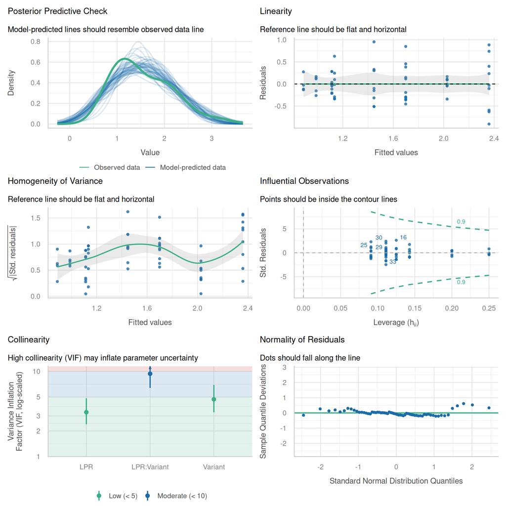

(a) Maximum amplitude

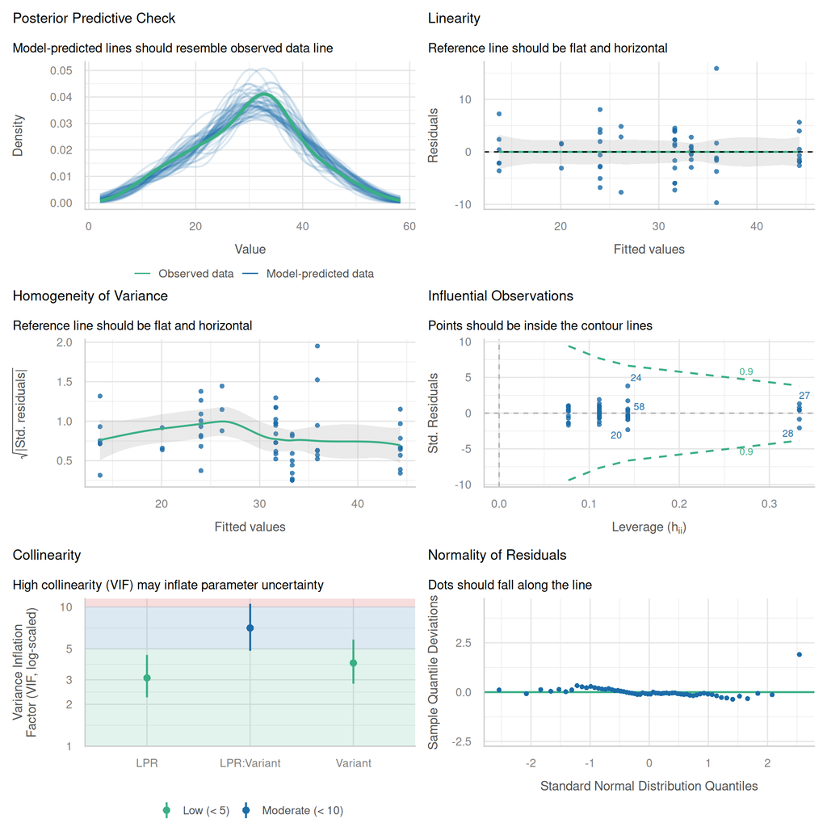

(b) Decay rate

```r
performance::check_model(model4_amp_lm, size_title=6)

performance::check_model(model4_k_lm, size_title=6)
```

On the whole the diagnostic plots do not indicate issues, except for the `LPR:Variant` correlation. However, as this is an interaction term, the collinearity is likely a result of “essential ill-conditioning” and unavoidable. As the interactions are not indicated to have any great effect on the model we proceed with the model as it stands, and extract the contrasts in Table 3.

```r
EMM1 <- emmeans::emmeans(model4_amp_lm, ~ LPR | Variant)
confint(emmeans::contrast(EMM1, "pairwise", adjust="sidak")) |>
  kableExtra::kbl(digits=3) |>
  kableExtra::kable_styling(
    bootstrap_options = c("hover", "responsive")
  )
EMM2 <- emmeans::emmeans(model4_k_lm, ~ LPR | Variant)
confint(emmeans::contrast(EMM2, "pairwise", adjust="sidak")) |>
  kableExtra::kbl(digits=3) |>
  kableExtra::kable_styling(
    bootstrap_options = c("hover", "responsive")
  )
```

Table 3: Contrasts for model fits, with Sidak adjustment

(a) Maximum amplitude: change `LPR`, constant `Variant`

| contrast | Variant | estimate | SE | df | lower.CL | upper.CL |
| --- | --- | --- | --- | --- | --- | --- |
| LPR5 - LPR10 | WT | 0.914 | 0.183 | 54 | 0.546 | 1.281 |
| LPR5 - LPR10 | H170A | 0.459 | 0.221 | 54 | 0.015 | 0.903 |
| LPR5 - LPR10 | H170D | 0.810 | 0.227 | 54 | 0.355 | 1.265 |
| LPR5 - LPR10 | H170E | 1.225 | 0.196 | 54 | 0.832 | 1.617 |

(b) Decay rate: change `LPR`, constant `Variant`

| contrast | Variant | estimate | SE | df | lower.CL | upper.CL |
| --- | --- | --- | --- | --- | --- | --- |
| LPR5 - LPR10 | WT | 11.023 | 2.125 | 52 | 6.759 | 15.286 |
| LPR5 - LPR10 | H170A | 9.725 | 3.110 | 52 | 3.484 | 15.966 |
| LPR5 - LPR10 | H170D | 11.563 | 2.887 | 52 | 5.770 | 17.356 |
| LPR5 - LPR10 | H170E | 10.290 | 2.271 | 52 | 5.733 | 14.848 |

## Figure

We visualise this with $p$-values in Figure 3, which we interpret as the change from `LPR5` to `LPR10` inducing a significant reduction in maximum amplitude and decay rate constant for all three variants.

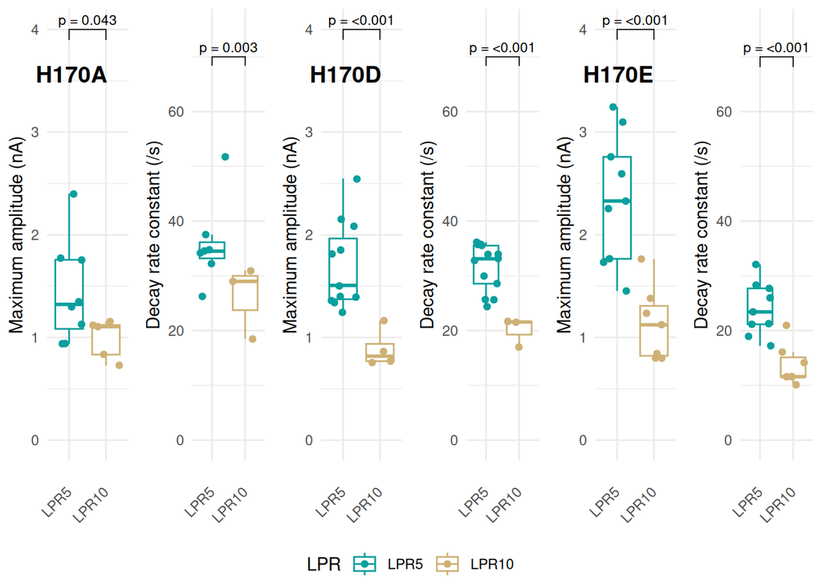

Figure 3: `H170` variant measurements across `LPR5` and `LPR10` as in figure 5B from the draft manuscript , with Sidak-adjusted *p*-values indicated

```r
# Get p-values, accounting for heteroscedasticity and multiple testing
# Also generate group1 and group2 columns
EMM_amp <- as.data.frame(pairs(EMM1)) |>
  tidyr::separate(contrast, into=c("group1", "group2"), sep=" - ") |>
  dplyr::mutate(y.position=4) |>
  rstatix::add_significance()
EMM_k <- as.data.frame(pairs(EMM2)) |>
  tidyr::separate(contrast, into=c("group1", "group2"), sep=" - ") |>
  dplyr::mutate(y.position=70) |>
  rstatix::add_significance()

p4_h170a_amp_annot <- p4_h170a_amp +
  ggpubr::stat_pvalue_manual(EMM_amp |> dplyr::filter(Variant == "H170A"), label="p = {scales::pvalue(p.value)}",
                             size=3, step.increase=0.1)
p4_h170a_k_annot <- p4_h170a_k +
  ggpubr::stat_pvalue_manual(EMM_k |> dplyr::filter(Variant == "H170A"), label="p = {scales::pvalue(p.value)}",
                             size=3, step.increase=0.1)
p4_h170d_amp_annot <- p4_h170d_amp +
  ggpubr::stat_pvalue_manual(EMM_amp |> dplyr::filter(Variant == "H170D"), label="p = {scales::pvalue(p.value)}",
                             size=3, step.increase=0.1)
p4_h170d_k_annot <- p4_h170d_k +
  ggpubr::stat_pvalue_manual(EMM_k |> dplyr::filter(Variant == "H170D"), label="p = {scales::pvalue(p.value)}",
                             size=3, step.increase=0.1)
p4_h170e_amp_annot <- p4_h170e_amp +
  ggpubr::stat_pvalue_manual(EMM_amp |> dplyr::filter(Variant == "H170E"), label="p = {scales::pvalue(p.value)}",
                             size=3, step.increase=0.1)
p4_h170e_k_annot <- p4_h170e_k +
  ggpubr::stat_pvalue_manual(EMM_k |> dplyr::filter(Variant == "H170E"), label="p = {scales::pvalue(p.value)}",
                             size=3, step.increase=0.1)


p_comp <- ggpubr::ggarrange(p4_h170a_amp_annot, p4_h170a_k_annot,
                            p4_h170d_amp_annot, p4_h170d_k_annot,
                            p4_h170e_amp_annot, p4_h170e_k_annot,
                            common.legend=TRUE,
                            labels=c("H170A", "", "H170D", "", "H170E", ""), vjust=5,
                            legend="bottom",
                            nrow=1)
p_comp

# Write figures to file (commented out for webpage)
#ggplot2::ggsave("assets/images/fig05_H170_mutants.pdf", p_comp)
#ggplot2::ggsave("assets/images/fig05_H170_mutants.png", p_comp)
```

### Downloads

- Download as .pdf
- Download as .png

## Additional Contrasts

There are further contrasts used as evidence in the manuscript text. The question arises whether there is a significant difference between `WT` and `H170` variant maximum amplitude or decay rate constant at `LPR5`, which we explore in Table 4. This indicates a difference in maximum amplitude between `WT` and `H170A` (but not `H170D` or `H170E`), and a difference in decay rate constant between `WT` and all `H170` variants, at `LPR5`.

```r
EMM1 <- emmeans::emmeans(model4_amp_lm, ~ Variant | LPR)
confint(emmeans::contrast(EMM1, "pairwise", adjust="sidak")) |>
  kableExtra::kbl(digits=3) |>
  kableExtra::kable_styling(
    bootstrap_options = c("hover", "responsive")
  )
EMM2 <- emmeans::emmeans(model4_k_lm, ~ Variant | LPR)
confint(emmeans::contrast(EMM2, "pairwise", adjust="sidak")) |>
  kableExtra::kbl(digits=3) |>
  kableExtra::kable_styling(
    bootstrap_options = c("hover", "responsive")
  )
```

Table 4: Further contrasts for model fits

(a) Maximum amplitude: changes between `Variant` at each `LPR`

| contrast | LPR | estimate | SE | df | lower.CL | upper.CL |
| --- | --- | --- | --- | --- | --- | --- |
| WT - H170A | LPR5 | 0.580 | 0.189 | 54 | 0.064 | 1.095 |
| WT - H170D | LPR5 | 0.328 | 0.175 | 54 | -0.149 | 0.805 |
| WT - H170E | LPR5 | -0.332 | 0.183 | 54 | -0.832 | 0.168 |
| H170A - H170D | LPR5 | -0.252 | 0.181 | 54 | -0.745 | 0.241 |
| H170A - H170E | LPR5 | -0.912 | 0.189 | 54 | -1.427 | -0.396 |
| H170D - H170E | LPR5 | -0.660 | 0.175 | 54 | -1.137 | -0.183 |
| WT - H170A | LPR10 | 0.125 | 0.217 | 54 | -0.467 | 0.717 |
| WT - H170D | LPR10 | 0.224 | 0.233 | 54 | -0.413 | 0.862 |
| WT - H170E | LPR10 | -0.021 | 0.196 | 54 | -0.556 | 0.513 |
| H170A - H170D | LPR10 | 0.099 | 0.261 | 54 | -0.612 | 0.811 |
| H170A - H170E | LPR10 | -0.146 | 0.227 | 54 | -0.768 | 0.475 |
| H170D - H170E | LPR10 | -0.246 | 0.244 | 54 | -0.911 | 0.419 |

(b) Decay rate: changes between `Variant` at each `LPR`

| contrast | LPR | estimate | SE | df | lower.CL | upper.CL |
| --- | --- | --- | --- | --- | --- | --- |
| WT - H170A | LPR5 | 8.451 | 2.271 | 52 | 2.239 | 14.663 |
| WT - H170D | LPR5 | 12.699 | 1.954 | 52 | 7.354 | 18.044 |
| WT - H170E | LPR5 | 20.319 | 2.125 | 52 | 14.508 | 26.130 |
| H170A - H170D | LPR5 | 4.248 | 2.113 | 52 | -1.530 | 10.027 |
| H170A - H170E | LPR5 | 11.868 | 2.271 | 52 | 5.656 | 18.080 |
| H170D - H170E | LPR5 | 7.620 | 1.954 | 52 | 2.275 | 12.965 |
| WT - H170A | LPR10 | 7.153 | 3.005 | 52 | -1.065 | 15.371 |
| WT - H170D | LPR10 | 13.240 | 3.005 | 52 | 5.022 | 21.457 |
| WT - H170E | LPR10 | 19.587 | 2.271 | 52 | 13.375 | 25.799 |
| H170A - H170D | LPR10 | 6.087 | 3.680 | 52 | -3.978 | 16.151 |
| H170A - H170E | LPR10 | 12.434 | 3.110 | 52 | 3.928 | 20.940 |
| H170D - H170E | LPR10 | 6.347 | 3.110 | 52 | -2.159 | 14.853 |